# SST Paper generation Wave 1 Only

Ben Smith

2022-12-19

This file just generates the stuf that goes into the final paper. # Prep

```r
library(tidyverse)
library(MuMIn)
Sys.setenv(R_CONFIG_ACTIVE = Sys.info()["nodename"])
print(Sys.info()["nodename"])
```

```
##                        nodename
## "Benjamins-MacBook-Pro-2.local"
```

```r
library(stargazer)
library(tidyverse)
library(gt)
source("preprocessing.R")
source("display_utils.R")
library(lmerTest)
dropbbox_dir <- config::get("dev_analysis_data_dir")
output_folder <- "sst_paper_generation_w1_no_prop_correct_threshold_output"
```

```r
cache_filepath <- paste0(dropbbox_dir,"sst_paper_generation_w1_no_prop_correct_threshold.Rdata")
loaded_from_cache<-FALSE
if (file.exists(cache_filepath)){
  load(cache_filepath)
  loaded_from_cache<-TRUE
} else
{
  time_points_raw <- readr::read_csv(paste0(dropbbox_dir,"/SST_roi_by_time_point.csv")) %>% filter(wave %in% c(1))
  #now only include subjects that have been deemed includeable
  #this is the set that made up the ROI.
  included_subjects_table <-readr::read_csv(paste0(config::get("level2_output_path"),
                                    "conditions_20230616/raw_filelist.csv"))
  included_subjects <- included_subjects_table$subject_id
  time_points<-time_points_raw[time_points_raw$subid %in% included_subjects_table$subject_id,]
}
```

```r
if(!loaded_from_cache){
  roi_cols <- colnames(time_points)[grepl("harvardoxford",colnames(time_points))]
time_points$tr_roi_mean <- rowMeans(time_points[,roi_cols])
time_points<-
  time_points %>% group_by(subid,wave) %>%
  mutate(run_mean_across_rois = mean(tr_roi_mean, na.rm = TRUE))

#now mean-center the ROIs
time_points_c<-time_points
for (roi_col in roi_cols){
  time_points_c[,roi_col]<-time_points_c[,roi_col]-time_points_c$run_mean_across_rois
}


roi_detect_pattern<-"((?<=harvardoxford-.{0,3}cortical_prob_)(.*))|(CueFollowing\\(CS\\>FS\\).*)"
anatomical_rois_detect_pattern <- "(?<=harvardoxford-.{0,3}cortical_prob_)(.*)"

roi_cols_vec <- colnames(time_points_c) %>% stringr::str_detect(pattern = roi_detect_pattern)
new_roi_cols <- colnames(time_points_c) %>% stringr::str_extract_all(pattern = roi_detect_pattern) %>% unlist
anatomical_roi_cols <- colnames(time_points_c) %>% stringr::str_extract_all(pattern = anatomical_rois_detect_pattern) %>% unlist
unique(new_roi_cols)
colnames(time_points_c)[roi_cols_vec] <- new_roi_cols

}
```

We need to group by subject, wave, and trial, select just the FailedStop trials, and just the high trial numbers, then get the min and max accumbens activity. We could even do a long transform across the ROIs, then also group by ROI and get the min and max for ROIs

So let’s first long transform the ROIs

Then do the grouping and summarizing.

```r
if(!loaded_from_cache){
  tpc_long<-time_points_c %>% pivot_longer(cols=all_of(new_roi_cols),names_to="ROI",values_to="value")

  trial_summary_data <- tpc_long %>%
    #filter(condition=="FailedStop") %>%
    group_by(subid,wave,trial_n,ROI, condition) %>%
    summarise(
      peak=max(value[offset>=4.0 & offset <=11.0],na.rm = TRUE),
      trough = min(value[offset>=4.0 & offset <=11.0],na.rm = TRUE),
      peak_time = offset[offset>=4.0 & offset <=11.0][value[offset>=4.0 & offset <=11.0]==max(value[offset>=4.0 & offset <=11.0],na.rm = TRUE)],
      trough_time = offset[offset>=4.0 & offset <=11.0][value[offset>=4.0 & offset <=11.0]==min(value[offset>=4.0 & offset <=11.0],na.rm = TRUE)],
      med_post_trial = median(value[offset>=4.0 & offset <=10.0],na.rm = TRUE),
      med_post_trial_1_5 = median(value[offset>=1.0 & offset <=5.0],na.rm = TRUE)


    )


  trial_summary_data$response_amplitude <-trial_summary_data$peak-trial_summary_data$trough
}
```

OK. So now, let’s try to merge in that with post-pre RTs. Where do we get those from?

## get the SST Post-pre data

```r
source(paste0(config::get("ben_dev_data_analysis"),"SST_processing.R"))

dropbox_file_dir = config::get("dev_analysis_data_dir")

sst_all_data_filepath <- paste0(dropbox_file_dir,"sst_behavioral_data_all.csv")

if(!loaded_from_cache){

  sst_all_data_raw <- readr::read_csv(sst_all_data_filepath)  %>% filter(waveid %in% c(1))
  sst_all_data<-clean_sst_data(sst_all_data_raw)
  sst_all_data <- get_expected_tone_time(sst_all_data)

  sst_all_data<-calculate_response_latency(sst_all_data)
  sst_all_data<-calculate_rpe(sst_all_data)

  sst_all_data<-get_more_sst_stats(sst_all_data)

  #remove subjects with too many incorrect trials--theyre' probably not paying attention

}
```

```r
if(!loaded_from_cache){
  sst_all_data_accuracy <- sst_all_data %>% select(-numchunks_reciprocal,-ladder_movement,-rundatetime,-RPE_SSD_based,-RPE_SSD_RT_diff,-ssrt_0)
  prop_correct_included_range <- c(0.2,0.8)
  print("before removing very high and low performance trials:")
  print(sst_all_data$subid %>% unique %>% length)
  # sst_all_data <- sst_all_data %>% filter(
  #   stop_prop_correct>prop_correct_included_range[[1]] &
  #     stop_prop_correct<prop_correct_included_range[[2]])
  print("after removing very high and low performance trials:")
  print(sst_all_data$subid %>% unique %>% length)
  #readr::write_csv(sst_all_data,file=paste0(dropbox_file_dir,"sst_behavioral_data_all_with_analysis_w1.csv"))

  post_pre_rt_data <- sst_all_data%>% filter(condition!="Cue")
}
```

## Prepare neural data

```r
if(!loaded_from_cache){
  trial_summary_data$ROI_delateralized <-  trial_summary_data$ROI %>% str_replace_all("(Left|Right)\\s","")


  trial_summary_data_delat <- trial_summary_data %>%
    #filter(ROI %in% c("Left Accumbens","Right Accumbens")) %>%
    group_by(subid,wave,trial_n, ROI_delateralized,condition) %>%
    summarize(peak=mean(peak),
              trough=mean(trough),
              peak_time=mean(peak_time),
              trough_time=mean(trough_time),
              response_amplitude=mean(response_amplitude),
              med_post_trial=mean(med_post_trial),
              med_post_trial_1_5 = mean(med_post_trial_1_5)
              )
}
```

## Merge the datasets

```r
if(!loaded_from_cache){

  trial_summary_data_delat_pp <- merge(trial_summary_data_delat,post_pre_rt_data,by.x = c("subid","wave","trial_n","condition"),by.y=c("subid","waveid","trial_n","condition"),all.x = TRUE)

  trial_summary_data_delat_pp$trial_n_c<-128-trial_summary_data_delat_pp$trial_n

}
```

# Preparing regressors

```r
if(!loaded_from_cache){
  trial_neural_behav_data_not_na<-trial_summary_data_delat_pp[
    #rowSums(is.na(trial_summary_data_delat_pp[,c("response_amplitude","post_pre_rt_change")]))==0 & #no NA values in correlation and
    is.na(trial_summary_data_delat_pp[,c("post_pre_rt_change")])==FALSE & #no NA values in correlation and
      #is.finite(trial_summary_data_delat_pp$response_amplitude) #&
      is.finite(trial_summary_data_delat_pp$post_pre_rt_change) & #no infinite values
      (is.finite(trial_summary_data_delat_pp$med_post_trial) |
       is.finite(trial_summary_data_delat_pp$med_post_trial_1_5)
     )
      ,]

  trial_neural_behav_data_not_na$trial_n_c<-128-trial_neural_behav_data_not_na$trial_n


  trial_neural_behav_roi <- trial_neural_behav_data_not_na %>% filter(ROI_delateralized=="CueFollowing(CS>FS)striatal_cluster_combined")

  trial_neural_behav_roi$condition<-(
    factor(trial_neural_behav_roi$condition,
              levels=c("CorrectGo","CorrectStop","FailedGo","FailedStop"),
              ordered=FALSE))


  trial_neural_behav_roi$trial_n_s<-scale(trial_neural_behav_roi$trial_n_c)
  trial_neural_behav_roi$peak_z<-scale(trial_neural_behav_roi$peak)
  trial_neural_behav_roi$post_pre_rt_change_z<-scale(trial_neural_behav_roi$post_pre_rt_change)
  trial_neural_behav_roi$P_stop_trial_change_z<-scale(trial_neural_behav_roi$P_stop_trial_change)
  trial_neural_behav_roi$trial_n_z<-scale(trial_neural_behav_roi$trial_n)
  trial_neural_behav_roi$med_post_trial_z<-scale(trial_neural_behav_roi$med_post_trial)

}
```

# Prepare time series data

```r
if(!loaded_from_cache){
df_offset<-get_df_offset(time_points_c)
}
```

# Save cache

```r
if (!loaded_from_cache){
  save.image(cache_filepath)
}

#load(paste0(dropbbox_dir,"/sst_paper_generation.Rdata"))
```

# Accuracy

```r
#
# sst_all_data_accuracy_with_neural <- merge(trial_summary_data_delat,sst_all_data_accuracy,by.x = c("subid","wave","trial_n","condition"),by.y=c("subid","waveid","trial_n","condition"),all.x = TRUE)
#
# included_subjects <- unique(sst_all_data_accuracy_with_neural$subid)
# #length(included_subjects)
#
# sst_accuracy_by_run<-sst_all_data_accuracy %>% filter(waveid %in% c(1,2)) %>%
#   filter(subid %in% included_subjects) %>%
#   group_by(subid,waveid,runid) %>%
#
#   dplyr::summarise(stop_prop_correct=mean(stop_prop_correct),
#          stop_prop_correct_nunique=length(unique(stop_prop_correct))
#          )
#
# sst_accuracy_by_run$stop_prop_correct_too_low<-sst_accuracy_by_run$stop_prop_correct<prop_correct_included_range[[1]]
# sst_accuracy_by_run$stop_prop_correct_too_high<-sst_accuracy_by_run$stop_prop_correct>prop_correct_included_range[[2]]
# sst_accuracy_by_run$included<-(!sst_accuracy_by_run$stop_prop_correct_too_low & !sst_accuracy_by_run$stop_prop_correct_too_high)
#
#
# sst_accuracy_by_subject <- sst_accuracy_by_run %>% filter(waveid %in% c(1,2)) %>%
#   filter(subid %in% included_subjects) %>% group_by(subid) %>% summarise(
#   AnyRunRemoved=any(!included),
#   AnyRunRetained=any(included),
#   AllRunsRetained=all(included)
#   )
#
# removed_runs <- sst_accuracy_by_run[sst_accuracy_by_run$included==FALSE,]
#
#
# print("removed runs:")
# print(removed_runs)
#
# print(table(removed_runs$stop_prop_correct_too_low))
# print(table(removed_runs$stop_prop_correct_too_high))
#
#
# fig_accuracy_supp<-ggplot(sst_accuracy_by_run,aes(x=stop_prop_correct, fill=included))+
#   geom_histogram(bins=25, color="black")+labs(
#     title="Included and excluded runs by proportion stop trials correct",
#     y="Number of runs",x="Proportion of Stop Trials Correct")+
#   scale_x_continuous(labels=scales::percent_format())+
#   theme(legend.position = "bottom")+geom_vline(xintercept=prop_correct_included_range)+
#   #geom_vline(xintercept=spc_sd_2_pos,color="red")+
#   annotate("text", x = prop_correct_included_range[1], y = 60, label = "Lower Limit ", hjust = "right") +
#   annotate("text", x = prop_correct_included_range[2], y = 60, label =" Upper Limit", hjust = "left")# +
#   # annotate("text", x = spc_sd_2_pos[1], y = 60, label = "2 SD", hjust = "right") +
#   # annotate("text", x = spc_sd_2_pos[2], y = 60, label = "2 SD", hjust = "left")
#
# removal_summary_stats<-sst_accuracy_by_run %>% ungroup %>% group_by(subid) %>% summarise(
#   AnyRunRemoved=any(!included),
#   AnyRunRetained=any(included),
#   AllRunsRetained=all(included)
#   )
#
#
# print(table(removal_summary_stats$AnyRunRetained))
#
# #removal_summary_stats[removal_summary_stats$AnyRunRetained,"subid"]
# subjects_removed_entirely<-removal_summary_stats[!removal_summary_stats$AnyRunRetained,"subid"] %>% unlist()
#
# #sst_accuracy_by_run[sst_accuracy_by_run$subid %in% subjects_removed_entirely,]
#
# ggsave(paste0(output_folder, "/fig_accuracy_supp.svg"),width = 6,height=4)
# ggsave(paste0(output_folder, "/fig_accuracy_supp.png"),width = 6,height=4)
```

# Basic Striatal cluster mixed effects models

# All trial types, with P_Stop

I think if you’re going to do P_stop

- P_stop_trial seems mostly irrelevant and P_stop_trial_post is a more relevant measure; P_stop_trial_change is more relevant still.
- measuring P_stop_trial rather than P_stop_trial_change doesn’t make much sense, but
- If you’re only measuring FS, neither P_stop_trial_post nor P_stop_trial_change are necessarily going to measure what you think because the data is censored to just FS trials, which are *always* going to move in a particular direction
- so while measuring `P_stop_trial`, it’s best to do a model with all kinds of trials

## Table 1: stop conditions, with condition

Modeled in more detail in `modeling_t_5_10_activity_as_learning.Rmd`.

```r
model_full_effects <- lme4::lmer(
   med_post_trial_z ~ trial_n_s+ condition + P_stop_trial_change_z+ post_pre_rt_change_z + (1 +post_pre_rt_change_z  + P_stop_trial_change_z  | subid),
  trial_neural_behav_roi %>% filter(trial_n>50 & condition %in% c("CorrectStop","FailedStop"))
  )
```

```
## boundary (singular) fit: see help('isSingular')
```

```r
summary(model_full_effects)
```

```
## Linear mixed model fit by REML ['lmerMod']
## Formula: med_post_trial_z ~ trial_n_s + condition + P_stop_trial_change_z +
##     post_pre_rt_change_z + (1 + post_pre_rt_change_z + P_stop_trial_change_z |
##     subid)
##    Data: trial_neural_behav_roi %>% filter(trial_n > 50 & condition %in%
##     c("CorrectStop", "FailedStop"))
##
## REML criterion at convergence: 8584.5
##
## Scaled residuals:
##     Min      1Q  Median      3Q     Max
## -4.9780 -0.6426  0.0057  0.6251  3.7833
##
## Random effects:
##  Groups   Name                  Variance Std.Dev. Corr
##  subid    (Intercept)           0.000000 0.00000
##           post_pre_rt_change_z  0.002864 0.05351    NaN
##           P_stop_trial_change_z 0.137804 0.37122    NaN -1.00
##  Residual                       1.004962 1.00248
## Number of obs: 3002, groups:  subid, 217
##
## Fixed effects:
##                       Estimate Std. Error t value
## (Intercept)           -0.68350    0.14486  -4.718
## trial_n_s             -0.33595    0.05847  -5.746
## conditionFailedStop   -0.47020    0.03772 -12.465
## P_stop_trial_change_z  2.61553    0.42523   6.151
## post_pre_rt_change_z  -0.02200    0.01846  -1.191
##
## Correlation of Fixed Effects:
##             (Intr) trl_n_ cndtFS P_s___
## trial_n_s    0.930
## cndtnFldStp -0.033  0.077
## P_stp_trl__ -0.980 -0.913 -0.082
## pst_pr_rt__ -0.042 -0.022 -0.146  0.007
## optimizer (nloptwrap) convergence code: 0 (OK)
## boundary (singular) fit: see help('isSingular')
```

```r
model_no_rt<- lme4::lmer(
   med_post_trial_z ~ trial_n_s+ condition + P_stop_trial_change_z + (1 +post_pre_rt_change_z  + P_stop_trial_change_z  | subid),
  trial_neural_behav_roi %>% filter(trial_n>50 & condition %in% c("CorrectStop","FailedStop"))
  )
```

```
## boundary (singular) fit: see help('isSingular')
```

```r
anova(model_full_effects,model_no_rt)
```

```
## refitting model(s) with ML (instead of REML)
```

```
## Data: trial_neural_behav_roi %>% filter(trial_n > 50 & condition %in%  ...
## Models:
## model_no_rt: med_post_trial_z ~ trial_n_s + condition + P_stop_trial_change_z + (1 + post_pre_rt_change_z + P_stop_trial_change_z | subid)
## model_full_effects: med_post_trial_z ~ trial_n_s + condition + P_stop_trial_change_z + post_pre_rt_change_z + (1 + post_pre_rt_change_z + P_stop_trial_change_z | subid)
##                    npar    AIC    BIC  logLik deviance Chisq Df Pr(>Chisq)
## model_no_rt          11 8575.3 8641.4 -4276.7   8553.3
## model_full_effects   12 8586.0 8658.1 -4281.0   8562.0     0  1          1
```

```r
model_no_p_stop<- lme4::lmer(
   med_post_trial_z ~ trial_n_s+ condition + post_pre_rt_change_z + (1 +post_pre_rt_change_z  + P_stop_trial_change_z  | subid),
  trial_neural_behav_roi %>% filter(trial_n>50 & condition %in% c("CorrectStop","FailedStop"))
  )

anova(model_full_effects,model_no_p_stop)
```

```
## refitting model(s) with ML (instead of REML)
```

```
## Data: trial_neural_behav_roi %>% filter(trial_n > 50 & condition %in%  ...
## Models:
## model_no_p_stop: med_post_trial_z ~ trial_n_s + condition + post_pre_rt_change_z + (1 + post_pre_rt_change_z + P_stop_trial_change_z | subid)
## model_full_effects: med_post_trial_z ~ trial_n_s + condition + P_stop_trial_change_z + post_pre_rt_change_z + (1 + post_pre_rt_change_z + P_stop_trial_change_z | subid)
##                    npar    AIC    BIC  logLik deviance  Chisq Df Pr(>Chisq)
## model_no_p_stop      11 8606.4 8672.5 -4292.2   8584.4
## model_full_effects   12 8586.0 8658.1 -4281.0   8562.0 22.402  1  2.211e-06 ***
## ---
## Signif. codes:  0 '***' 0.001 '**' 0.01 '*' 0.05 '.' 0.1 ' ' 1
```

```r
model_list <- list("RT Change Only, Excluding P(Stop) Change"=model_no_p_stop,
                   "P(Stop) Change Only, Excluding RT Change"=model_no_rt,
                   "Full model"=model_full_effects
                   )


friendly_name_transform_table<-read_csv("friendly_names.csv")
#save(model_list, file="temp_state.Rdata")
table_cells <- create_sst_mlm_table(
  model_list,name_transform =friendly_name_transform_table)
```

```
## refitting model(s) with ML (instead of REML)
## refitting model(s) with ML (instead of REML)
## refitting model(s) with ML (instead of REML)
```

[output not shown]

The below code block is designed to do some testing.

```r
#debugSource("~/Google Drive/oregon/code/DEV_scripts/fMRI/fx/models/SST/direct_regression/display_utils.R")
#load("temp_state.Rdata")
# table_cells <- create_sst_mlm_table(
#   model_list,name_transform =friendly_name_transform_table,do_model_comparison=TRUE)
```

```r
gtsave(table_cells,filename = "sst_paper_generation_w12_output/table1.html")
```

```r
anova(model_full_effects,model_no_p_stop, model_no_rt)
```

```
## refitting model(s) with ML (instead of REML)
```

```
## Data: trial_neural_behav_roi %>% filter(trial_n > 50 & condition %in%  ...
## Models:
## model_no_p_stop: med_post_trial_z ~ trial_n_s + condition + post_pre_rt_change_z + (1 + post_pre_rt_change_z + P_stop_trial_change_z | subid)
## model_no_rt: med_post_trial_z ~ trial_n_s + condition + P_stop_trial_change_z + (1 + post_pre_rt_change_z + P_stop_trial_change_z | subid)
## model_full_effects: med_post_trial_z ~ trial_n_s + condition + P_stop_trial_change_z + post_pre_rt_change_z + (1 + post_pre_rt_change_z + P_stop_trial_change_z | subid)
##                    npar    AIC    BIC  logLik deviance  Chisq Df Pr(>Chisq)
## model_no_p_stop      11 8606.4 8672.5 -4292.2   8584.4
## model_no_rt          11 8575.3 8641.4 -4276.7   8553.3 31.089  0
## model_full_effects   12 8586.0 8658.1 -4281.0   8562.0  0.000  1          1
```

### Predicted vs. ground truth

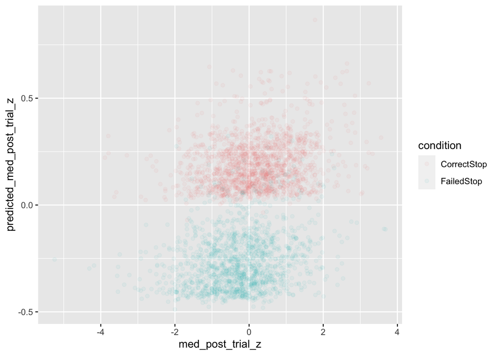

```r
relevant_data<- trial_neural_behav_roi %>% filter(trial_n>50 & condition %in% c("CorrectStop","FailedStop"))
predicted_overall_rpe <- predict(model_full_effects,relevant_data)
relevant_data$predicted_med_post_trial_z<-predicted_overall_rpe

ggplot(relevant_data,aes(x=med_post_trial_z,y=predicted_med_post_trial_z,color=condition))+geom_point(alpha=0.05)
```

```r
cor.test(relevant_data$med_post_trial_z,relevant_data$predicted_med_post_trial_z)
```

```
##
##  Pearson's product-moment correlation
##
## data:  relevant_data$med_post_trial_z and relevant_data$predicted_med_post_trial_z
## t = 16.364, df = 3000, p-value < 2.2e-16
## alternative hypothesis: true correlation is not equal to 0
## 95 percent confidence interval:
##  0.2530827 0.3187755
## sample estimates:
##       cor
## 0.2862655
```

```r
r.squaredGLMM(model_full_effects)
```

```
##             R2m        R2c
## [1,] 0.06067024 0.07180706
```

# Looking at CS and FS trials separately.

## Table 2: Just FS Trials

Modeled in more detail in `modeling_t_5_10_activity_as_learning.Rmd`.

### median

```r
is_not_na<-(
  !is.na(trial_neural_behav_roi$med_post_trial_z) &
    !is.na(trial_neural_behav_roi$trial_n_z) &
    !is.na(trial_neural_behav_roi$post_pre_rt_change_z) &
    !is.na(trial_neural_behav_roi$P_stop_trial_change_z) &
    !is.na(trial_neural_behav_roi$subid))


relevant_data <- trial_neural_behav_roi %>% filter(trial_n>50 & condition %in% c("FailedStop") & is_not_na)
model_P_stop_trial_w_change <- lme4::lmer(
   med_post_trial_z ~ trial_n_z + post_pre_rt_change_z + P_stop_trial_change_z +(1+ post_pre_rt_change_z + P_stop_trial_change_z  | subid),
  relevant_data
  )
```

```
## boundary (singular) fit: see help('isSingular')
```

```r
summary(model_P_stop_trial_w_change)
```

```
## Linear mixed model fit by REML ['lmerMod']
## Formula:
## med_post_trial_z ~ trial_n_z + post_pre_rt_change_z + P_stop_trial_change_z +
##     (1 + post_pre_rt_change_z + P_stop_trial_change_z | subid)
##    Data: relevant_data
##
## REML criterion at convergence: 4014.3
##
## Scaled residuals:
##     Min      1Q  Median      3Q     Max
## -4.9810 -0.6030  0.0245  0.5833  3.4246
##
## Random effects:
##  Groups   Name                  Variance Std.Dev. Corr
##  subid    (Intercept)           0.344747 0.58715
##           post_pre_rt_change_z  0.002526 0.05026  -0.24
##           P_stop_trial_change_z 2.362433 1.53702  -0.94 -0.11
##  Residual                       0.943870 0.97153
## Number of obs: 1405, groups:  subid, 213
##
## Fixed effects:
##                       Estimate Std. Error t value
## (Intercept)           -1.28012    0.20856  -6.138
## trial_n_z              0.42097    0.08268   5.092
## post_pre_rt_change_z  -0.02519    0.02580  -0.976
## P_stop_trial_change_z  2.85190    0.59594   4.786
##
## Correlation of Fixed Effects:
##             (Intr) trl_n_ ps____
## trial_n_z   -0.915
## pst_pr_rt__ -0.120  0.055
## P_stp_trl__ -0.984  0.897  0.047
## optimizer (nloptwrap) convergence code: 0 (OK)
## boundary (singular) fit: see help('isSingular')
```

```r
#ignoring post_pre_rt_change_z
model_P_stop_trial_w_change_no_rt <- lme4::lmer(
   med_post_trial_z ~ trial_n_z  + P_stop_trial_change_z +(1+ post_pre_rt_change_z + P_stop_trial_change_z  | subid),
  relevant_data
  )
#summary(model_P_stop_trial_w_change_no_rt)

anova(model_P_stop_trial_w_change,model_P_stop_trial_w_change_no_rt)
```

```
## refitting model(s) with ML (instead of REML)
```

```
## Data: relevant_data
## Models:
## model_P_stop_trial_w_change_no_rt: med_post_trial_z ~ trial_n_z + P_stop_trial_change_z + (1 + post_pre_rt_change_z + P_stop_trial_change_z | subid)
## model_P_stop_trial_w_change: med_post_trial_z ~ trial_n_z + post_pre_rt_change_z + P_stop_trial_change_z + (1 + post_pre_rt_change_z + P_stop_trial_change_z | subid)
##                                   npar    AIC    BIC  logLik deviance  Chisq Df
## model_P_stop_trial_w_change_no_rt   10 4020.6 4073.1 -2000.3   4000.6
## model_P_stop_trial_w_change         11 4021.7 4079.4 -1999.8   3999.7 0.9419  1
##                                   Pr(>Chisq)
## model_P_stop_trial_w_change_no_rt
## model_P_stop_trial_w_change           0.3318
```

```r
#ignoring P_stop_trial_change_z
model_P_stop_trial_w_change_no_p_stop_d <- lme4::lmer(
   med_post_trial_z ~ trial_n_z +  post_pre_rt_change_z +(1+ post_pre_rt_change_z + P_stop_trial_change_z | subid),
  relevant_data
  )
```

```
## boundary (singular) fit: see help('isSingular')
```

```r
#summary(model_P_stop_trial_w_change_no_p_stop_d)


anova(model_P_stop_trial_w_change, model_P_stop_trial_w_change_no_p_stop_d)
```

```
## refitting model(s) with ML (instead of REML)
```

```
## Data: relevant_data
## Models:
## model_P_stop_trial_w_change_no_p_stop_d: med_post_trial_z ~ trial_n_z + post_pre_rt_change_z + (1 + post_pre_rt_change_z + P_stop_trial_change_z | subid)
## model_P_stop_trial_w_change: med_post_trial_z ~ trial_n_z + post_pre_rt_change_z + P_stop_trial_change_z + (1 + post_pre_rt_change_z + P_stop_trial_change_z | subid)
##                                         npar    AIC    BIC  logLik deviance
## model_P_stop_trial_w_change_no_p_stop_d   10 4043.1 4095.6 -2011.5   4023.1
## model_P_stop_trial_w_change               11 4021.7 4079.4 -1999.8   3999.7
##                                          Chisq Df Pr(>Chisq)
## model_P_stop_trial_w_change_no_p_stop_d
## model_P_stop_trial_w_change             23.388  1  1.324e-06 ***
## ---
## Signif. codes:  0 '***' 0.001 '**' 0.01 '*' 0.05 '.' 0.1 ' ' 1
```

```r
anova(model_P_stop_trial_w_change, model_P_stop_trial_w_change_no_rt, model_P_stop_trial_w_change_no_p_stop_d)
```

```
## refitting model(s) with ML (instead of REML)
```

```
## Data: relevant_data
## Models:
## model_P_stop_trial_w_change_no_rt: med_post_trial_z ~ trial_n_z + P_stop_trial_change_z + (1 + post_pre_rt_change_z + P_stop_trial_change_z | subid)
## model_P_stop_trial_w_change_no_p_stop_d: med_post_trial_z ~ trial_n_z + post_pre_rt_change_z + (1 + post_pre_rt_change_z + P_stop_trial_change_z | subid)
## model_P_stop_trial_w_change: med_post_trial_z ~ trial_n_z + post_pre_rt_change_z + P_stop_trial_change_z + (1 + post_pre_rt_change_z + P_stop_trial_change_z | subid)
##                                         npar    AIC    BIC  logLik deviance
## model_P_stop_trial_w_change_no_rt         10 4020.6 4073.1 -2000.3   4000.6
## model_P_stop_trial_w_change_no_p_stop_d   10 4043.1 4095.6 -2011.5   4023.1
## model_P_stop_trial_w_change               11 4021.7 4079.4 -1999.8   3999.7
##                                          Chisq Df Pr(>Chisq)
## model_P_stop_trial_w_change_no_rt
## model_P_stop_trial_w_change_no_p_stop_d  0.000  0
## model_P_stop_trial_w_change             23.388  1  1.324e-06 ***
## ---
## Signif. codes:  0 '***' 0.001 '**' 0.01 '*' 0.05 '.' 0.1 ' ' 1
```

```r
model_list <- list("RT Change Only, Excluding P(Stop) Change"=model_P_stop_trial_w_change_no_p_stop_d,
                   "P(Stop) Change Only, Excluding RT Change"=model_P_stop_trial_w_change_no_rt,
                   "Full model"=model_P_stop_trial_w_change
                   )


friendly_name_transform_table<-read_csv("friendly_names.csv")
table_cells <- create_sst_mlm_table(model_list,name_transform =friendly_name_transform_table,
  "Median Activity 4-10 s Post-Stop Signal")
```

```
## refitting model(s) with ML (instead of REML)
## refitting model(s) with ML (instead of REML)
## refitting model(s) with ML (instead of REML)
```

[output not shown]

```r
gtsave(table_cells,filename = "sst_paper_generation_w12_output/table2.html")
```

```r
sjplot_result <- sjPlot::tab_model(model_P_stop_trial_w_change)
```

```r
anova_model <- do.call(anova,
                       list(model_P_stop_trial_w_change, model_P_stop_trial_w_change_no_rt, model_P_stop_trial_w_change_no_p_stop_d))
```

```
## refitting model(s) with ML (instead of REML)
```

```r
anova_model$`Pr(>Chisq)`
```

```
## [1]           NA           NA 1.323987e-06
```

```r
model_P_stop_trial_w_change_summary <- summary(model_P_stop_trial_w_change)

#model_comparison_summary <- function(model_list){
model_list <- list("RT Only"=model_P_stop_trial_w_change_no_p_stop_d,
                   "Full model"=model_P_stop_trial_w_change,
                   "P(Stop) Only"=model_P_stop_trial_w_change_no_rt
                   )


fixed_effects_list <- sapply(model_list, custom_mixed_model_summary)

fixed_effects_df <- t(dplyr::bind_rows(fixed_effects_list))

model_comparison <- do.call(anova,unname(model_list))
```

```
## refitting model(s) with ML (instead of REML)
```

```r
anova_model_order <- rownames(model_comparison) %>% str_extract("\\d+") %>% as.numeric
#anova re-organizes its results depending on which are better fit.
#we can do the same to the rest of the data, or we can re-organize back to how we had it.


anova_raw_result_df <- t(data.frame(model_comparison)[,c("npar", "AIC", "BIC", "logLik", "Chisq","Pr..Chisq.")])
anova_reorganized_list <- rep(list(NA),length(anova_model_order))
#to re-orgnize back
for (ri in 1:length(anova_model_order)){
  anova_reorganized_list[[ri]] <- anova_raw_result_df[,which(anova_model_order==ri)]
}
anova_result_df_input_order <- do.call(rbind, anova_reorganized_list)
#or we can organize the fixed effects in terms of the anova
#I think that is better...
fixed_effects_df_anova_order <- fixed_effects_df[,anova_model_order]
#then we can merge it with the anova results
anova_low_precision<-c( "AIC", "BIC", "logLik")
anova_med_precision<-c("Chisq")
anova_p_precision<-c("Pr..Chisq.")
anova_results_tided<-anova_raw_result_df
anova_results_tided[anova_low_precision,]<-round(anova_results_tided[anova_low_precision,],0)
anova_results_tided[anova_med_precision,]<-round(anova_results_tided[anova_med_precision,],2)
anova_results_tided[anova_p_precision,]<-format.pval(anova_results_tided[anova_p_precision,])
table_cells <- rbind(fixed_effects_df_anova_order,anova_results_tided)
```

```r
#table_normed <- stargazer(model_P_stop_trial_w_change, model_P_stop_trial_w_change_no_rt, model_P_stop_trial_w_change_no_p_stop_d,title="asis Markdown")
```

#### R^2 variance explained estimate

```r
r.squaredGLMM(model_P_stop_trial_w_change)
```

```
##           R2m        R2c
## [1,] 0.019147 0.09673403
```

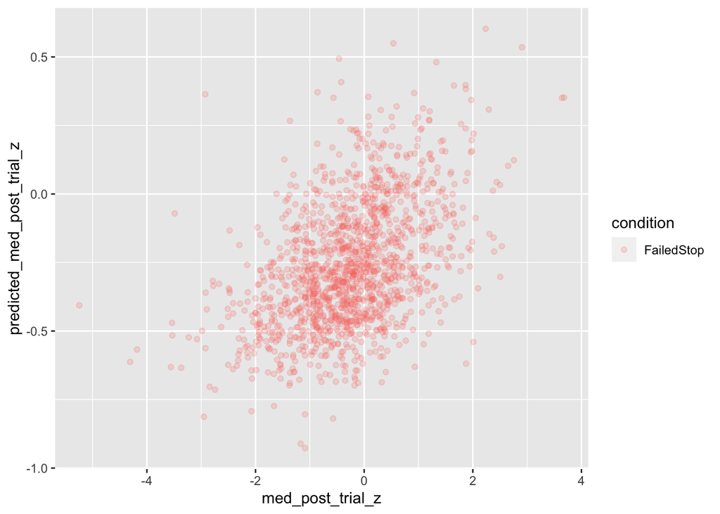

```r
relevant_data <- trial_neural_behav_roi %>% filter(trial_n>50 & condition %in% c("FailedStop") & is_not_na)

relevant_data$predicted_med_post_trial_z <- predict(model_P_stop_trial_w_change,relevant_data)

ggplot(relevant_data,aes(x=med_post_trial_z,y=predicted_med_post_trial_z,color=condition))+geom_point(alpha=0.2)
```

### median, all trials

```r
model_P_stop_trial_w_change <- lme4::lmer(
   med_post_trial_z ~ trial_n_z + post_pre_rt_change_z + P_stop_trial_change_z +(1+ post_pre_rt_change_z + P_stop_trial_change_z  | subid),
  trial_neural_behav_roi %>% filter(condition %in% c("FailedStop"))
  )
summary(model_P_stop_trial_w_change)
```

```
## Linear mixed model fit by REML ['lmerMod']
## Formula:
## med_post_trial_z ~ trial_n_z + post_pre_rt_change_z + P_stop_trial_change_z +
##     (1 + post_pre_rt_change_z + P_stop_trial_change_z | subid)
##    Data: trial_neural_behav_roi %>% filter(condition %in% c("FailedStop"))
##
## REML criterion at convergence: 6183
##
## Scaled residuals:
##     Min      1Q  Median      3Q     Max
## -4.8925 -0.6111  0.0323  0.6199  3.8183
##
## Random effects:
##  Groups   Name                  Variance  Std.Dev. Corr
##  subid    (Intercept)           0.0550789 0.23469
##           post_pre_rt_change_z  0.0003088 0.01757  -0.84
##           P_stop_trial_change_z 0.0049618 0.07044  -0.19  0.69
##  Residual                       0.9754675 0.98766
## Number of obs: 2152, groups:  subid, 217
##
## Fixed effects:
##                        Estimate Std. Error t value
## (Intercept)           -0.228446   0.032868  -6.950
## trial_n_z              0.000795   0.023545   0.034
## post_pre_rt_change_z  -0.003739   0.021147  -0.177
## P_stop_trial_change_z -0.103074   0.018568  -5.551
##
## Correlation of Fixed Effects:
##             (Intr) trl_n_ ps____
## trial_n_z   -0.144
## pst_pr_rt__ -0.386  0.025
## P_stp_trl__ -0.475  0.488  0.194
```

```r
#ignoring post_pre_rt_change_z
model_P_stop_trial_w_change_no_rt <- lme4::lmer(
   med_post_trial_z ~ trial_n_z  + P_stop_trial_change_z +(1+ post_pre_rt_change_z + P_stop_trial_change_z  | subid),
  trial_neural_behav_roi %>% filter(condition %in% c("FailedStop"))
  )
summary(model_P_stop_trial_w_change_no_rt)
```

```
## Linear mixed model fit by REML ['lmerMod']
## Formula:
## med_post_trial_z ~ trial_n_z + P_stop_trial_change_z + (1 + post_pre_rt_change_z +
##     P_stop_trial_change_z | subid)
##    Data: trial_neural_behav_roi %>% filter(condition %in% c("FailedStop"))
##
## REML criterion at convergence: 6177.2
##
## Scaled residuals:
##     Min      1Q  Median      3Q     Max
## -4.8965 -0.6104  0.0350  0.6194  3.8194
##
## Random effects:
##  Groups   Name                  Variance  Std.Dev. Corr
##  subid    (Intercept)           0.0550239 0.23457
##           post_pre_rt_change_z  0.0003155 0.01776  -0.84
##           P_stop_trial_change_z 0.0049489 0.07035  -0.19  0.68
##  Residual                       0.9750642 0.98745
## Number of obs: 2152, groups:  subid, 217
##
## Fixed effects:
##                         Estimate Std. Error t value
## (Intercept)           -0.2306859  0.0303110  -7.611
## trial_n_z              0.0009051  0.0235319   0.038
## P_stop_trial_change_z -0.1024335  0.0182072  -5.626
##
## Correlation of Fixed Effects:
##             (Intr) trl_n_
## trial_n_z   -0.146
## P_stp_trl__ -0.442  0.493
## optimizer (nloptwrap) convergence code: 0 (OK)
## Model failed to converge with max|grad| = 0.0492167 (tol = 0.002, component 1)
```

```r
anova(model_P_stop_trial_w_change,model_P_stop_trial_w_change_no_rt)
```

```
## refitting model(s) with ML (instead of REML)
```

```
## Data: trial_neural_behav_roi %>% filter(condition %in% c("FailedStop"))
## Models:
## model_P_stop_trial_w_change_no_rt: med_post_trial_z ~ trial_n_z + P_stop_trial_change_z + (1 + post_pre_rt_change_z + P_stop_trial_change_z | subid)
## model_P_stop_trial_w_change: med_post_trial_z ~ trial_n_z + post_pre_rt_change_z + P_stop_trial_change_z + (1 + post_pre_rt_change_z + P_stop_trial_change_z | subid)
##                                   npar    AIC    BIC  logLik deviance  Chisq Df
## model_P_stop_trial_w_change_no_rt   10 6179.7 6236.4 -3079.8   6159.7
## model_P_stop_trial_w_change         11 6181.6 6244.1 -3079.8   6159.6 0.0301  1
##                                   Pr(>Chisq)
## model_P_stop_trial_w_change_no_rt
## model_P_stop_trial_w_change           0.8624
```

```r
#ignoring P_stop_trial_change_z
model_P_stop_trial_w_change_no_p_stop_d <- lme4::lmer(
   med_post_trial_z ~ trial_n_z +  post_pre_rt_change_z +(1+ post_pre_rt_change_z + P_stop_trial_change_z | subid),
  trial_neural_behav_roi %>% filter(condition %in% c("FailedStop"))
  )
```

```
## boundary (singular) fit: see help('isSingular')
```

```r
summary(model_P_stop_trial_w_change_no_p_stop_d)
```

```
## Linear mixed model fit by REML ['lmerMod']
## Formula:
## med_post_trial_z ~ trial_n_z + post_pre_rt_change_z + (1 + post_pre_rt_change_z +
##     P_stop_trial_change_z | subid)
##    Data: trial_neural_behav_roi %>% filter(condition %in% c("FailedStop"))
##
## REML criterion at convergence: 6206
##
## Scaled residuals:
##     Min      1Q  Median      3Q     Max
## -4.9155 -0.6101  0.0252  0.6241  3.7364
##
## Random effects:
##  Groups   Name                  Variance  Std.Dev. Corr
##  subid    (Intercept)           0.0649916 0.25493
##           post_pre_rt_change_z  0.0005041 0.02245  -1.00
##           P_stop_trial_change_z 0.0097945 0.09897  -0.41  0.41
##  Residual                       0.9811358 0.99052
## Number of obs: 2152, groups:  subid, 217
##
## Fixed effects:
##                      Estimate Std. Error t value
## (Intercept)          -0.31640    0.02919  -10.84
## trial_n_z             0.05843    0.02087    2.80
## post_pre_rt_change_z  0.01572    0.02095    0.75
##
## Correlation of Fixed Effects:
##             (Intr) trl_n_
## trial_n_z    0.125
## pst_pr_rt__ -0.356 -0.071
## optimizer (nloptwrap) convergence code: 0 (OK)
## boundary (singular) fit: see help('isSingular')
```

```r
anova(model_P_stop_trial_w_change, model_P_stop_trial_w_change_no_p_stop_d)
```

```
## refitting model(s) with ML (instead of REML)
```

```
## Data: trial_neural_behav_roi %>% filter(condition %in% c("FailedStop"))
## Models:
## model_P_stop_trial_w_change_no_p_stop_d: med_post_trial_z ~ trial_n_z + post_pre_rt_change_z + (1 + post_pre_rt_change_z + P_stop_trial_change_z | subid)
## model_P_stop_trial_w_change: med_post_trial_z ~ trial_n_z + post_pre_rt_change_z + P_stop_trial_change_z + (1 + post_pre_rt_change_z + P_stop_trial_change_z | subid)
##                                         npar    AIC    BIC  logLik deviance
## model_P_stop_trial_w_change_no_p_stop_d   10 6208.9 6265.6 -3094.4   6188.9
## model_P_stop_trial_w_change               11 6181.6 6244.1 -3079.8   6159.6
##                                          Chisq Df Pr(>Chisq)
## model_P_stop_trial_w_change_no_p_stop_d
## model_P_stop_trial_w_change             29.202  1  6.521e-08 ***
## ---
## Signif. codes:  0 '***' 0.001 '**' 0.01 '*' 0.05 '.' 0.1 ' ' 1
```

#### distribution thereof

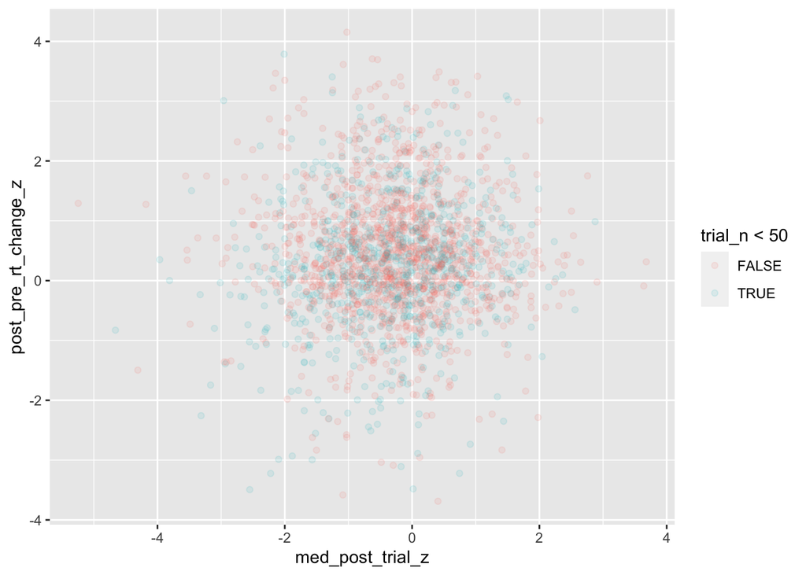

```r
# plot a ggplot2 point graph of trial_neural_behav_roi filtered by FailedStop, plotting med_post_trial_z against post_pre_rt_change_z
# coloring points by whether trial_n is <50 or not

ggplot(data = trial_neural_behav_roi %>%
          filter(condition=="FailedStop"),
        aes(x = med_post_trial_z,
            y = post_pre_rt_change_z,
            color = trial_n < 50)) +
   geom_point(alpha=0.1)
```

# Table 3: Post-Fail Spike

This is modeled in more detail in `modeling_t_1_5_activity_as_learning.Rmd`. ## Just FS Trials

```r
count_subs <- function(ds){length(unique(ds$subid))}

count_subs(trial_summary_data)
```

```
## [1] 217
```

```r
count_subs(trial_summary_data_delat)
```

```
## [1] 217
```

```r
count_subs(trial_summary_data_delat_pp)
```

```
## [1] 217
```

```r
count_subs(trial_neural_behav_data_not_na)
```

```
## [1] 217
```

```r
subjects_in_table_3_analysis <- unique(trial_neural_behav_roi$subid)
length(subjects_in_table_3_analysis)
```

```
## [1] 217
```

```r
#print(subjects_in_table_3_analysis)
```

```r
model_P_stop_trial_w_change <- lme4::lmer(
   med_post_trial_1_5 ~ trial_n_z + post_pre_rt_change_z + P_stop_trial_change_z +(1+ post_pre_rt_change_z + P_stop_trial_change_z  | subid),
  trial_neural_behav_roi %>% filter(trial_n>50 & condition %in% c("FailedStop"))
  )
```

```
## boundary (singular) fit: see help('isSingular')
```

```r
summary(model_P_stop_trial_w_change)
```

```
## Linear mixed model fit by REML ['lmerMod']
## Formula:
## med_post_trial_1_5 ~ trial_n_z + post_pre_rt_change_z + P_stop_trial_change_z +
##     (1 + post_pre_rt_change_z + P_stop_trial_change_z | subid)
##    Data: trial_neural_behav_roi %>% filter(trial_n > 50 & condition %in%
##     c("FailedStop"))
##
## REML criterion at convergence: 1765.9
##
## Scaled residuals:
##     Min      1Q  Median      3Q     Max
## -6.3248 -0.5553  0.0397  0.6124  3.2438
##
## Random effects:
##  Groups   Name                  Variance Std.Dev. Corr
##  subid    (Intercept)           0.00000  0.0000
##           post_pre_rt_change_z  0.01469  0.1212     NaN
##           P_stop_trial_change_z 0.12162  0.3487     NaN -0.21
##  Residual                       0.18174  0.4263
## Number of obs: 1405, groups:  subid, 213
##
## Fixed effects:
##                        Estimate Std. Error t value
## (Intercept)           -0.199933   0.091277  -2.190
## trial_n_z              0.098482   0.036712   2.683
## post_pre_rt_change_z  -0.004069   0.014922  -0.273
## P_stop_trial_change_z  0.773614   0.263607   2.935
##
## Correlation of Fixed Effects:
##             (Intr) trl_n_ ps____
## trial_n_z   -0.935
## pst_pr_rt__ -0.094  0.047
## P_stp_trl__ -0.980  0.907  0.028
## optimizer (nloptwrap) convergence code: 0 (OK)
## boundary (singular) fit: see help('isSingular')
```

```r
#ignoring post_pre_rt_change_z
model_P_stop_trial_w_change_no_rt <- lme4::lmer(
   med_post_trial_1_5 ~ trial_n_z  + P_stop_trial_change_z +(1+ post_pre_rt_change_z + P_stop_trial_change_z  | subid),
  trial_neural_behav_roi %>% filter(trial_n>50 & condition %in% c("FailedStop"))
  )
```

```
## boundary (singular) fit: see help('isSingular')
```

```r
#summary(model_P_stop_trial_w_change_no_rt)

anova(model_P_stop_trial_w_change,model_P_stop_trial_w_change_no_rt)
```

```
## refitting model(s) with ML (instead of REML)
```

```
## Data: trial_neural_behav_roi %>% filter(trial_n > 50 & condition %in%  ...
## Models:
## model_P_stop_trial_w_change_no_rt: med_post_trial_1_5 ~ trial_n_z + P_stop_trial_change_z + (1 + post_pre_rt_change_z + P_stop_trial_change_z | subid)
## model_P_stop_trial_w_change: med_post_trial_1_5 ~ trial_n_z + post_pre_rt_change_z + P_stop_trial_change_z + (1 + post_pre_rt_change_z + P_stop_trial_change_z | subid)
##                                   npar    AIC    BIC  logLik deviance  Chisq Df
## model_P_stop_trial_w_change_no_rt   10 1765.4 1817.9 -872.69   1745.4
## model_P_stop_trial_w_change         11 1767.3 1825.0 -872.66   1745.3 0.0721  1
##                                   Pr(>Chisq)
## model_P_stop_trial_w_change_no_rt
## model_P_stop_trial_w_change           0.7884
```

```r
#ignoring P_stop_trial_change_z
model_P_stop_trial_w_change_no_p_stop_d <- lme4::lmer(
   med_post_trial_1_5 ~ trial_n_z +  post_pre_rt_change_z +(1+ post_pre_rt_change_z + P_stop_trial_change_z | subid),
  trial_neural_behav_roi %>% filter(trial_n>50 & condition %in% c("FailedStop"))
  )
```

```
## boundary (singular) fit: see help('isSingular')
```

```r
#summary(model_P_stop_trial_w_change_no_p_stop_d)


anova(model_P_stop_trial_w_change, model_P_stop_trial_w_change_no_p_stop_d)
```

```
## refitting model(s) with ML (instead of REML)
```

```
## Data: trial_neural_behav_roi %>% filter(trial_n > 50 & condition %in%  ...
## Models:
## model_P_stop_trial_w_change_no_p_stop_d: med_post_trial_1_5 ~ trial_n_z + post_pre_rt_change_z + (1 + post_pre_rt_change_z + P_stop_trial_change_z | subid)
## model_P_stop_trial_w_change: med_post_trial_1_5 ~ trial_n_z + post_pre_rt_change_z + P_stop_trial_change_z + (1 + post_pre_rt_change_z + P_stop_trial_change_z | subid)
##                                         npar    AIC    BIC  logLik deviance
## model_P_stop_trial_w_change_no_p_stop_d   10 1773.9 1826.4 -876.95   1753.9
## model_P_stop_trial_w_change               11 1767.3 1825.0 -872.66   1745.3
##                                          Chisq Df Pr(>Chisq)
## model_P_stop_trial_w_change_no_p_stop_d
## model_P_stop_trial_w_change             8.5877  1   0.003384 **
## ---
## Signif. codes:  0 '***' 0.001 '**' 0.01 '*' 0.05 '.' 0.1 ' ' 1
```

```r
model_list <- list("RT Change Only, Excluding P(Stop) Change"=model_P_stop_trial_w_change_no_p_stop_d,
                   "P(Stop) Change Only, Excluding RT Change "=model_P_stop_trial_w_change_no_rt,
                   "Full model"=model_P_stop_trial_w_change
                   )


friendly_name_transform_table<-read_csv("friendly_names.csv")
table_cells <- create_sst_mlm_table(
  model_list,name_transform =friendly_name_transform_table,
  "Median Activity 1-5 s Post-Stop Signal")
```

```
## refitting model(s) with ML (instead of REML)
## refitting model(s) with ML (instead of REML)
## refitting model(s) with ML (instead of REML)
```

[output not shown]

```r
gtsave(table_cells,filename = "sst_paper_generation_w12_output/table3.html")
```

```r
#table_normed <- stargazer(model_P_stop_trial_w_change, model_P_stop_trial_w_change_no_rt, model_P_stop_trial_w_change_no_p_stop_d,title="Post-Fail Spike")
#
```

#### Variance explained

```r
r.squaredGLMM(model_P_stop_trial_w_change)
```

```
##              R2m       R2c
## [1,] 0.006226854 0.1420074
```

# get the delay to next trial

```r
behavioral_data_w_tone_data <- readr::read_csv(paste0(dropbbox_dir,"/sst_behavioral_data_all_w_class_type_reveal_onset.csv")) %>% filter(waveid %in% c(1))
```

```
## ──────────────────────────────────────────────────────── Delimiter: "," chr
## (4): subid, go_no_go_condition_label, condition, health_condition_label dbl
## (25): ...1, trial_n, numchunks_reciprocal, go_no_go_condition, arrow_pr... dttm
## (1): rundatetime
```

```r
# I want to know: what is the time delay from the tone sound to the PERIOD of the next trial?
```

```r
#so I want to match each trial up with the _next_ trial
#grab the set of next trials-we want their onset and their duration
#then match that back onto n+1 of their prior trial
trial_df <- behavioral_data_w_tone_data %>% filter(condition!="Cue") %>%
  arrange(trial_n) %>%
  group_by(subid,waveid,runid) %>%
  mutate(next_trial_n = lead(trial_n,1)) %>%
  ungroup()


next_trial_df <- behavioral_data_w_tone_data %>%
  filter(condition!="Cue") %>%
  select(trial_n,condition,onset,trial_duration,subid,waveid,runid)


trials_with_next<-merge(
  trial_df,next_trial_df,
  by.x = c("subid","waveid","runid", "next_trial_n"),
  by.y=c("subid","waveid","runid","trial_n"),
  suffixes = c("","_next"))
```

now, mark for each trial the start and end time point of the next trial, and get measures of how long after each trial the next one appears

```r
trials_with_next$trial_end_next <- trials_with_next$onset_next+trials_with_next$trial_duration_next
trials_with_next$class_type_reveal_onset_to_next_trial_start<-trials_with_next$onset_next-trials_with_next$class_type_reveal_onset
trials_with_next$class_type_reveal_onset_to_next_trial_end<-trials_with_next$trial_end_next-trials_with_next$class_type_reveal_onset
```

```r
next_trial_median <- data.frame(
  "next_trial_start_median" = median(trials_with_next$class_type_reveal_onset_to_next_trial_start),
  "next_trial_end_median" = median(trials_with_next$class_type_reveal_onset_to_next_trial_end)
  )

quantiles <- (1:10)/10
# next_trial_gradient <- data.frame(
#   "quantiles" = quantiles,
#   "next_trial_start" = quantile(trials_with_next$class_type_reveal_onset_to_next_trial_start,(1:10)/10),
#   "next_trial_end" = quantile(trials_with_next$class_type_reveal_onset_to_next_trial_end,(1:10)/10)
#   )

gradient_range = seq(floor(min(trials_with_next$class_type_reveal_onset_to_next_trial_start)),ceiling(max(trials_with_next$class_type_reveal_onset_to_next_trial_end)),0.1)

in_range_by_gradient <- sapply(gradient_range,function(tp){
  time_point_is_after_start <- tp > trials_with_next$class_type_reveal_onset_to_next_trial_start
  time_point_is_before_end <- tp < trials_with_next$class_type_reveal_onset_to_next_trial_end
  number_of_trials <- length(trials_with_next$class_type_reveal_onset_to_next_trial_start)
  return(sum(time_point_is_after_start & time_point_is_before_end)/number_of_trials)
})

next_trial_gradient <- data.frame("tp"=gradient_range,"pct_in_range"=in_range_by_gradient)
next_trial_gradient$hrf_tp<-next_trial_gradient$tp+5
```

# do graphs

```r
subj_count <- length(unique(time_points_c$subid))
#df_offset_long<-df_offset# %>% pivot_longer(cols=roi_cols,names_to="ROI_fullname",values_to="value")
# df_offset_long$ROI<-stringr::str_extract_all(df_offset_long$ROI_fullname,pattern = "(?<=harvardoxford\\..{0,3}cortical_prob_)(.*)") %>% sub("\\."," ",.)

# unique_rois<-sort(unique(df_offset_long$ROI))
# unique_rois_ordered <- unique_rois[order(unique_rois %>% str_extract("(?<=.{3,5}\\s)(.*)"))]

# df_offset_long$ROI<-factor(df_offset_long$ROI,levels = unique_rois_ordered, ordered=TRUE)

ggplot_time_points_extras <- list(
  geom_vline(xintercept = 0,linetype="dashed"),
  geom_hline(yintercept = 0,linetype="dotted"),
  labs(
    x="time from tone sound or expected time of tone (s)",
    y="mean BOLD activity (no HRF convolution)",
    #title="Stop Signal Task Activity",
    subtitle=paste0("Across ", as.character(subj_count)," subjects with two sessions of 128 trials each"),
    caption="0 point is the moment of tone sound (Stop trials)\n or expected tone sound based on prior trial (Go trials)\n HRF convolution not applied\n1 s moving averages")
  )


plot_final<-ggplot(df_offset,
       aes(x=offset_start, y=`CueFollowing(CS>FS)striatal_cluster_combined`,color=condition))+
  geom_line()+
  #facet_wrap(~ROI,ncol = 2)+
  ggplot_time_points_extras

  #geom_point()+
  #geom_smooth(method="loess",span=2,na.rm=TRUE) + #https://ggplot2.tidyverse.org/reference/geom_smooth.html
  #scale_y_continuous(limits=c(-2.5,2.5))

#ggsave(paste0(output_folder, "/figure_1.svg"))


#plot_final
```

## CS-FS

Let’s now try to contrast these time series to see what the CS-FS looks like. This will be interesting because it’s similar to the simple GLM result I got earlier that set me down the path of trying to analyze this.

```r
trial_tps_compare_conditions<-df_offset %>% pivot_wider(
  id_cols=c(offset_start),
  names_from = "condition",
  values_from="CueFollowing(CS>FS)striatal_cluster_combined"
  )
trial_tps_compare_conditions$CS_minus_FS<-trial_tps_compare_conditions$CorrectStop-trial_tps_compare_conditions$FailedStop
```

### Figure 2:

```r
figure_2 <- ggplot(trial_tps_compare_conditions,
       aes(x=offset_start, y=CS_minus_FS))+
  #geom_tile(data = next_trial_gradient, aes(x=tp,alpha=pct_in_range,y=0),fill="#000000",color="transparent")+
  geom_tile(data = next_trial_gradient, aes(x=hrf_tp,alpha=pct_in_range,y=0),fill="#77ff77",color="transparent")+
  #annotate("text",x=4,y=0.25,label="Subsequent Go Trial\nTime Range",size=2)+
  annotate("text",x=10,y=0.22,label="Subsequent Go Trial\nExpected HRF",size=2)+
  scale_alpha_continuous(name="Subsequent go trial range", range=c(0,0.7),labels=scales::percent_format())+
  geom_line(size=1,alpha=0.5)+
  scale_color_viridis_d(option = "C")+
  ggplot_time_points_extras+
  coord_cartesian(ylim=c(-0.15,0.25))+
  labs(y="CS-FS BOLD activity difference")





ggsave(paste0(output_folder, "/figure_2.svg"),width = 6,height=4)

ggsave(paste0(output_folder, "/figure_2.png"),width = 6,height=4)
```

## Figure 3:

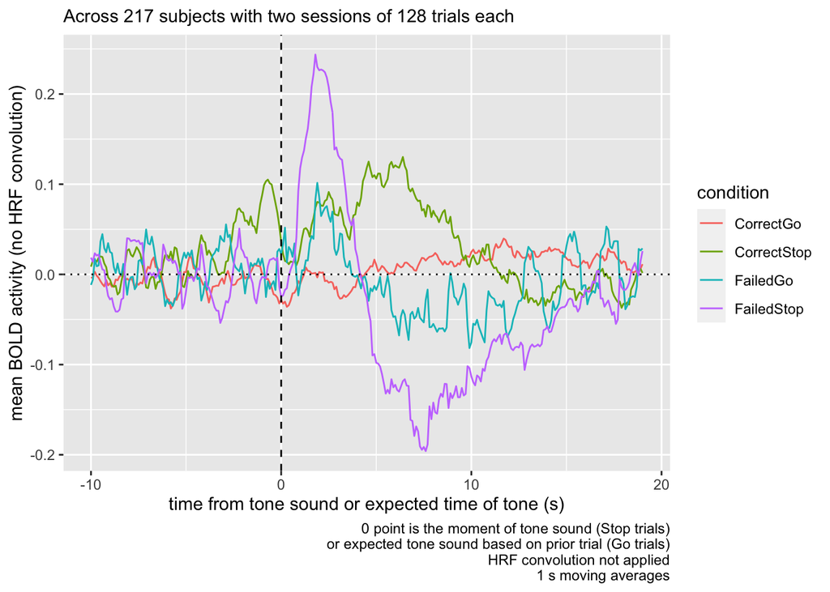

```r
count_subjs <- function(df){length(unique(df$subid))}
subj_count <- length(unique(time_points_c$subid))
figure_3 <- ggplot(df_offset,
       aes(x=offset_start, y=`CueFollowing(CS>FS)striatal_cluster_combined`,color=condition))+
  geom_line()+
  #facet_wrap(~ROI,ncol = 2)+
  ggplot_time_points_extras



ggsave(paste0(output_folder, "/figure_3.svg"),width = 6,height=4)

ggsave(paste0(output_folder, "/figure_3.png"),width = 6,height=4)

figure_3
```

# Figure 4 and 5

## Just stop trials, divided separately

```r
get_roi_good_names <- function(roi_fullname_col){

  roi_organized<-stringr::str_extract_all(unlist(roi_fullname_col),pattern = "(?<=harvardoxford\\.(sub)?cortical_prob_)(.*)") %>% sub("\\.\\.",", ",.) %>% gsub("\\."," ",.)
  #print(roi_organized)
  unique_rois<-sort(unique(roi_organized))
  unique_rois_ordered <- unique_rois[order(unique_rois %>% str_extract("(?<=.{3,5}\\s)(.*)"))]
  print(unique_rois)
  roi_factor_col<-factor(roi_organized,levels = unique_rois_ordered, ordered=TRUE)
  return(roi_factor_col)
}
```

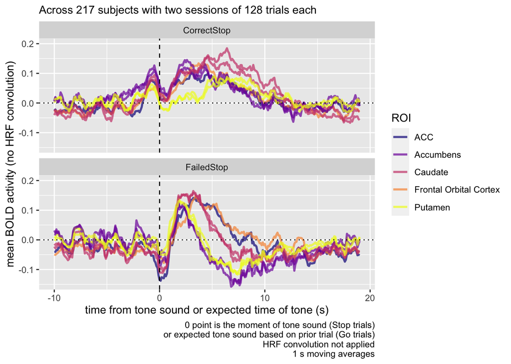

```r
#roi_cols <- colnames(df_offset)[grepl("harvardoxford",colnames(df_offset))]
df_offset_long<-df_offset %>% pivot_longer(cols=anatomical_roi_cols,names_to="ROI",values_to="value")

#df_offset_long$ROI<-get_roi_good_names(df_offset_long$ROI)
df_offset_long$ROI_bilat <- sub("(Left )|(Right )","",df_offset_long$ROI)
df_offset_long$ROI_bilat <- gsub("Cingulate Gyrus, anterior division","ACC",df_offset_long$ROI_bilat)

next_trial_gradient$hrf_tp<-next_trial_gradient$tp+5

figure_4 <- ggplot(df_offset_long %>% filter(condition %in% c("FailedStop","CorrectStop")),
       aes(x=offset_start, y=value,color=ROI_bilat,group=ROI))+
  facet_wrap(~condition,nrow = 2)+
  #geom_tile(data = next_trial_gradient, aes(x=hrf_tp,alpha=pct_in_range,y=0),fill="#77ff77",color="transparent")+
  #annotate("text",x=10,y=0.22,label="Subsequent Go Trial\nExpected HRF",size=2)+
  geom_line(size=1,alpha=0.7)+

  scale_color_viridis_d(option = "C")+
  coord_cartesian(ylim=c(-0.15,0.2))+
  guides(alpha="none",color=guide_legend(title="ROI"))+
  #guides(alpha="none",color=guide_legend(title="ROI",nrow = 2))+
  ggplot_time_points_extras#+
  #theme(legend.position = "bottom")

ggsave(paste0(output_folder, "/figure_4.svg"),width = 6,height=6)

ggsave(paste0(output_folder, "/figure_4.png"),width = 6,height=6)


figure_4
```

```r
#ggplot(df_offset_long,aes(x=offset_start, y=value,color=ROI,group=intersect(ROI,condition)))+geom_line()
  #geom_point()+
  #geom_smooth(method="loess",span=2,na.rm=TRUE) + #https://ggplot2.tidyverse.org/reference/geom_smooth.html
  #scale_y_continuous(limits=c(-2.5,2.5))
```

```r
trial_tps_compare_conditions<-df_offset_long %>% pivot_wider(id_cols=c(ROI, ROI_bilat,offset_start),names_from = "condition",values_from="value")
trial_tps_compare_conditions$CS_minus_FS<-trial_tps_compare_conditions$CorrectStop-trial_tps_compare_conditions$FailedStop
```

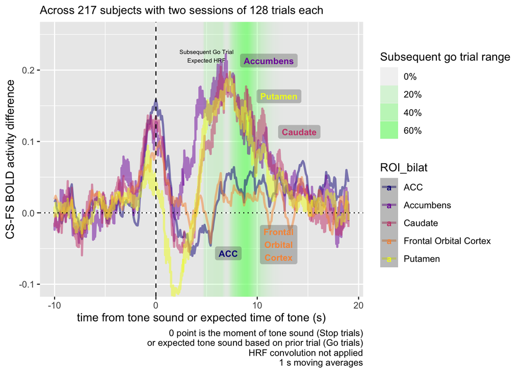

```r
library(directlabels)
library(ggrepel)

labels <- trial_tps_compare_conditions %>% filter(offset_start==9) %>% group_by(ROI_bilat) %>%
  slice(1)
#labels <- labels %>% mutate(y_pos=CS_minus_FS+(CS_minus_FS-mean(CS_minus_FS))*3)
labels$ROI_labels <- gsub(" ","\n",labels$ROI_bilat)
labels$ROI_bilat <- gsub("Cingulate\nGyrus,\nanterior\ndivision", "ACC",labels$ROI_bilat)


labels <- labels %>% arrange(ROI_labels)
#these need to be in alphabetical order
labels$xpos <- c(6,10,13,10,11)
labels$ypos <- c(-0.07,0.2,0.1,-0.07,0.15)

trial_tps_compare_conditions$ROI_bilat <- gsub("Cingulate Gyrus, anterior division","ACC",trial_tps_compare_conditions$ROI_bilat)

figure_5 <- ggplot(trial_tps_compare_conditions, aes(x=offset_start, y=CS_minus_FS,color=ROI_bilat))+
  geom_tile(data = next_trial_gradient, aes(x=hrf_tp,alpha=pct_in_range,y=0),fill="#77ff77",color="transparent")+

  annotate("text",x=5,y=0.22,label="Subsequent Go Trial\nExpected HRF",size=2)+
  scale_alpha_continuous(name="Subsequent go trial range", range=c(0,0.7),labels=scales::percent_format())+
  geom_line(size=1,alpha=0.5)+
  #geom_text(data=labels,mapping= aes(x=offset_start,y=CS_minus_FS,color=ROI_bilat,label=ROI_bilat))+
  # geom_text_repel(data = labels,  aes(x=offset_start,y=CS_minus_FS,label=ROI_labels),color="#333333",
  #                 size = 3, fontface = "bold",force=2,box.padding=0.1, point.padding = 10, nudge_x = -3*1.01,nudge_y = 0.01*1.1)+
  geom_label_repel(data = labels,
                   #aes(x=offset_start,y=y_pos,color=ROI_bilat,label=ROI_labels),
                   aes(x=xpos,y=ypos,color=ROI_bilat,label=ROI_labels),
                   size = 3, fontface = "bold",force=2,box.padding=0.1, label.size =0,
                   nudge_x = 1,nudge_y = 0.01,fill=rgb(0.3,0.3,0.3,alpha=0.3)
                   )+
  scale_color_viridis_d(option = "C")+
  ggplot_time_points_extras+
  coord_cartesian(ylim=c(-0.1,0.25))+
  labs(y="CS-FS BOLD activity difference")




ggsave(paste0(output_folder, "/figure_5.svg"),width = 6,height=4)

ggsave(paste0(output_folder, "/figure_5.png"),width = 6,height=4)


figure_5
```